# Bootstarpping from normal and exponential distributions

MessaA

June 8, 2016

#**Bootstrapping from normal random distribution**  
##** a) Sample with size=50, mean=25, SD=6**

```r
x<-rnorm(50,25,6)
M=mean(x)
Replicate<-1000
bootnorm1<-numeric(Replicate)
for(i in 1:Replicate){
temp<-sample(x,50,replace=T)
bootnorm1[i]<-mean(temp)
}
```

###**Summary of bootnorm1**

```r
summary(bootnorm1)
```

```
##    Min. 1st Qu.  Median    Mean 3rd Qu.    Max.
##   21.40   23.20   23.70   23.75   24.31   27.31
```

###**Comparing means and standard deviations of orginal sample and bootstrapsamples**

```r
M
```

```
## [1] 23.7555
```

```r
mean(bootnorm1)
```

```
## [1] 23.74926
```

```r
sd(x)
```

```
## [1] 5.853771
```

```r
sd(bootnorm1)
```

```
## [1] 0.8082431
```

###**Histogram of bootstarp samples and some comparisons such as means of orginal and bootstrap**

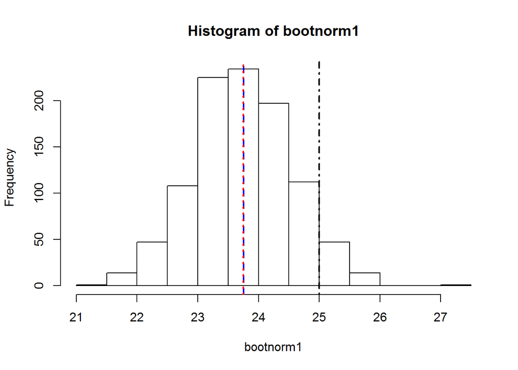

```r
hist(bootnorm1)
abline(v=M,col="blue", lwd=2, lty=2)
abline(v=mean(bootnorm1),col="red", lwd=2, lty=3)
abline(v=25,col="black", lwd=2, lty=4)
```

###**Estimation of bias which can be caused due to random samples of randoms and source of variablity of bootstraping itself**

```r
est.bias1<-M-mean(bootnorm1)
est.bias1
```

```
## [1] 0.006241065
```

[output not shown]

```r
x<-rnorm(100,25,6)
M2=mean(x)
Replicate<-1000
bootnorm2<-numeric(Replicate)
for(i in 1:Replicate){
temp<-sample(x,100,replace=T)
bootnorm2[i]<-mean(temp)
}
```

###**Summary of bootnorm2**

```r
summary(bootnorm2)
```

```
##    Min. 1st Qu.  Median    Mean 3rd Qu.    Max.
##   23.41   24.90   25.31   25.30   25.69   27.71
```

###**Comparing means and standard deviations of orginal sample and bootstrapsamples**

```r
M2
```

```
## [1] 25.31144
```

```r
mean(bootnorm2)
```

```
## [1] 25.3042
```

```r
sd(x)
```

```
## [1] 6.231514
```

```r
sd(bootnorm2)
```

```
## [1] 0.6229615
```

###**Histogram of bootstarp samples and some comparisons such as means of orginal and bootstrap**

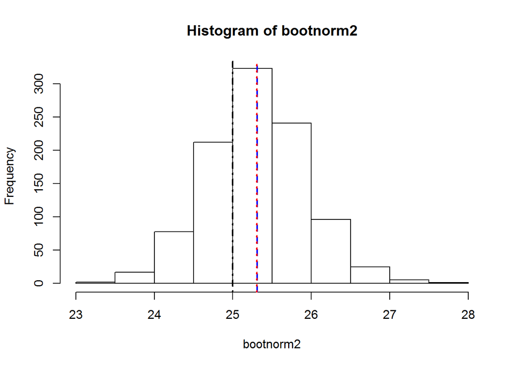

```r
hist(bootnorm2)
abline(v=M2,col="blue", lwd=2, lty=2)
abline(v=mean(bootnorm2),col="red", lwd=2, lty=3)
abline(v=25,col="black", lwd=2, lty=4)
```

###**Estimation of bias which can be caused due to random samples of randoms and source of variablity of bootstraping itself**

```r
est.bias2<-M2-mean(bootnorm2)
est.bias2
```

```
## [1] 0.007238221
```

#**Bootstrapping from exponential random distribution**  
##**a) Sample with size=75, lambda(rate)=0.2, where mean=sd=1/lambda**

```r
x<-rexp(75,0.2)
M3=mean(x)
Replicate<-1000
bootexp3<-numeric(Replicate)
for(i in 1:Replicate){
temp<-sample(x,75,replace=T)
bootexp3[i]<-mean(temp)
}
```

###**Summary of bootexp3**

```r
summary(bootexp3)
```

```
##    Min. 1st Qu.  Median    Mean 3rd Qu.    Max.
##   3.709   5.287   5.725   5.770   6.210   9.407
```

###**Comparing means and standard deviations of orginal sample and bootstrapsamples**

```r
M3
```

```
## [1] 5.749305
```

```r
mean(bootexp3)
```

```
## [1] 5.769931
```

```r
sd(x)
```

```
## [1] 5.734998
```

```r
sd(bootexp3)
```

```
## [1] 0.6926076
```

###**Histogram of bootstarp samples and some comparisons such as means of orginal and bootstrap**

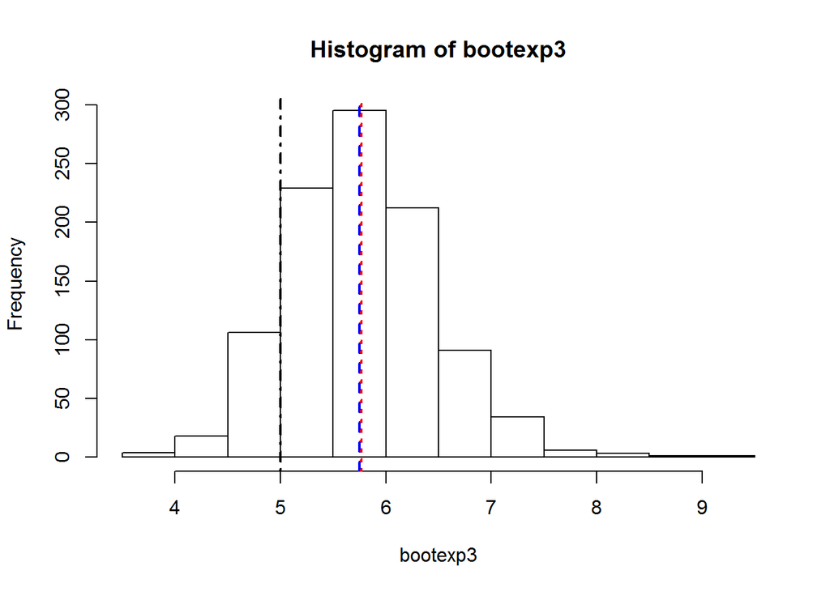

```r
hist(bootexp3)
abline(v=M3,col="blue", lwd=2, lty=2)
abline(v=mean(bootexp3),col="red", lwd=2, lty=3)
abline(v=5,col="black", lwd=2, lty=4)
```

###**Estimation of bias which can be caused due to random samples of randoms and source of variablity of bootstraping itself**

```r
est.bias3<-M3-mean(bootexp3)
est.bias3
```

```
## [1] -0.02062516
```

[output not shown]

```r
x<-rexp(200,0.2)
M4=mean(x)
Replicate<-1000
bootexp4<-numeric(Replicate)
for(i in 1:Replicate){
temp<-sample(x,200,replace=T)
bootexp4[i]<-mean(temp)
}
```

###**Summary of bootexp4**

```r
summary(bootexp4)
```

```
##    Min. 1st Qu.  Median    Mean 3rd Qu.    Max.
##   3.858   4.621   4.842   4.856   5.077   5.841
```

###**Comparing means and standard deviations of orginal sample and bootstrapsamples**

```r
M4
```

```
## [1] 4.852419
```

```r
mean(bootexp4)
```

```
## [1] 4.855608
```

```r
sd(x)
```

```
## [1] 4.744059
```

```r
sd(bootexp4)
```

```
## [1] 0.330082
```

###**Histogram of bootstarp samples and some comparisons such as means of orginal and bootstrap**

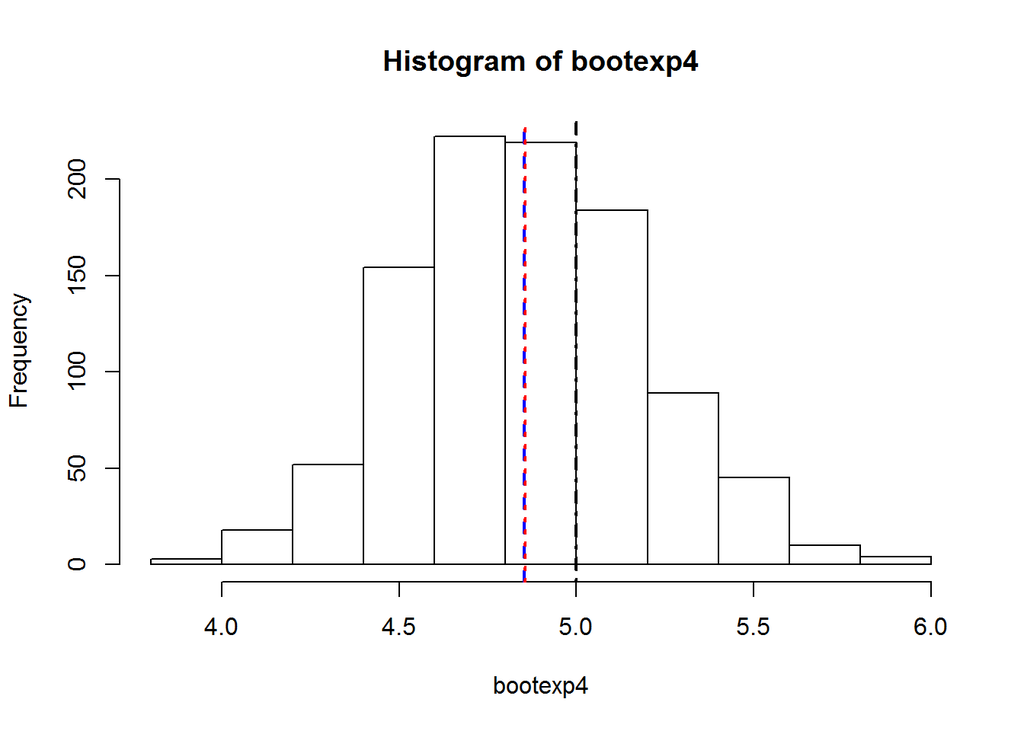

```r
hist(bootexp4)
abline(v=M4,col="blue", lwd=2, lty=2)
abline(v=mean(bootexp4),col="red", lwd=2, lty=3)
abline(v=5,col="black", lwd=2, lty=4)
```

###**Estimation of bias which can be caused due to random samples of randoms and source of variablity of bootstraping itself**

```r
est.bias4<-M4-mean(bootexp4)
est.bias4
```

```
## [1] -0.003189509
```